# Project 1

## Chandler Ellsworth and Kelley Breeze

# Overall Goal

- Write functions that will manipulate and process data sets that come in a certain form
- Create and fit basic linear regression models
- Create a cross-validation function to judge the models

The purpose of this project is to provide a guide as to how to read in and process data in python as well as create, test and judge linear models. We will also see how to create our own functions that can do these steps for us for similar data sets.

Throughout the project we will be working with data in the form of .csv files from the Census Bureau. The first two data sets contain information about public school enrollment. The last four data sets have information about resident population estimates, and will be used for double checking that our `combine_dataframes()` function generalizes for other census data sets. All of the data sets have the same general format, which will allow us to create functions that can streamline our workflow when reading in, parsing, and combining this data.

We will be breaking down the work into distinct steps to make things clear. First, we will begin by reading in and parsing the first education data set (`https://www4.stat.ncsu.edu/~online/datasets/EDU01a.csv`) in our **Data Processing** section. In the **Writing Functions to Help with Data Processing** section we will write our own functions that can accomplish what we achieved in the Data Processing steps, and use these functions to neatly read in and parse the second education data set (`https://www4.stat.ncsu.edu/~online/datasets/EDU01b.csv`). In the **Call It and Combine Our Data** section we will use the `wrapper()` function that we created to read in and parse our two .csv files that we have been working with and then combine them into a single object (a list with two data frames, one for county data and the other for non-county data) using our `combine_dataframes()` function. In the **Cross-Validation** section we will create a simple linear regression model and a multiple linear regression model for our non-county data, and evaluate them based on a cross-validation function that we will create.

Before getting started we will import the modules and functions that we will need to run our analyses.

```python
import pandas as pd
import numpy as np
from functools import reduce
from sklearn import linear_model
from sklearn.metrics import mean_squared_error
import seaborn as sns
import matplotlib.pyplot as plt
```

# Part 1: Data Processing

### Reading in the Data

First, we will read in the dataset from a url using the `pandas` `read_csv()` function. We will be reading in the dataset from the URL: `https://www4.stat.ncsu.edu/~online/datasets/EDU01a.csv` and saving it as a `pandas` dataframe called `censusdata`.

```python
censusdata = pd.read_csv('https://www4.stat.ncsu.edu/~online/datasets/EDU01a.csv')
```

Let's make sure that the file read in correctly using the `.head()` method from `pandas`.

```python
censusdata.head()
```

|  | Area_name | STCOU | EDU010187F | EDU010187D | EDU010187N1 | EDU010187N2 | EDU010188F | EDU010188D | EDU010188N1 | EDU010188N2 | ... | EDU010194N1 | EDU010194N2 | EDU010195F | EDU010195D | EDU010195N1 | EDU010195N2 | EDU010196F | EDU010196D | EDU010196N1 | EDU010196N2 |
| --- | --- | --- | --- | --- | --- | --- | --- | --- | --- | --- | --- | --- | --- | --- | --- | --- | --- | --- | --- | --- | --- |
| 0 | UNITED STATES | 0 | 0 | 40024299 | 0 | 0 | 0 | 39967624 | 0 | 0 | ... | 0 | 0 | 0 | 43993459 | 0 | 0 | 0 | 44715737 | 0 | 0 |
| 1 | ALABAMA | 1000 | 0 | 733735 | 0 | 0 | 0 | 728234 | 0 | 0 | ... | 0 | 0 | 0 | 727989 | 0 | 0 | 0 | 736825 | 0 | 0 |
| 2 | Autauga, AL | 1001 | 0 | 6829 | 0 | 0 | 0 | 6900 | 0 | 0 | ... | 0 | 0 | 0 | 7568 | 0 | 0 | 0 | 7834 | 0 | 0 |
| 3 | Baldwin, AL | 1003 | 0 | 16417 | 0 | 0 | 0 | 16465 | 0 | 0 | ... | 0 | 0 | 0 | 19961 | 0 | 0 | 0 | 20699 | 0 | 0 |
| 4 | Barbour, AL | 1005 | 0 | 5071 | 0 | 0 | 0 | 5098 | 0 | 0 | ... | 0 | 0 | 0 | 5017 | 0 | 0 | 0 | 5053 | 0 | 0 |

5 rows × 42 columns

### Data Processing Step 1: Selecting Columns in `pandas`

We first want to select specific columns from our `censusdata` dataframe. The columns that we want to select are:

- `Area_name` - we will rename this as `area_name`
- `STCOU`
- Any column that ends in "D" - we will use `.str.endswith()` method to help select only columns that end with "D"

We will select the desired columns using the `.loc[]` method. We will check the first few rows to make sure everything looks as expected again using the `.head()` method.

```python
censusdata.rename(columns = {'Area_name' : 'area_name'}, inplace = True)
censusdata = censusdata.loc[:, censusdata.columns.str.endswith(('D', 'area_name', 'STCOU'))]
censusdata.head()
```

|  | area_name | STCOU | EDU010187D | EDU010188D | EDU010189D | EDU010190D | EDU010191D | EDU010192D | EDU010193D | EDU010194D | EDU010195D | EDU010196D |
| --- | --- | --- | --- | --- | --- | --- | --- | --- | --- | --- | --- | --- |
| 0 | UNITED STATES | 0 | 40024299 | 39967624 | 40317775 | 40737600 | 41385442 | 42088151 | 42724710 | 43369917 | 43993459 | 44715737 |
| 1 | ALABAMA | 1000 | 733735 | 728234 | 730048 | 728252 | 725541 | 726150 | 728014 | 730509 | 727989 | 736825 |
| 2 | Autauga, AL | 1001 | 6829 | 6900 | 6920 | 6847 | 7008 | 7137 | 7152 | 7381 | 7568 | 7834 |
| 3 | Baldwin, AL | 1003 | 16417 | 16465 | 16799 | 17054 | 17479 | 17983 | 18735 | 19384 | 19961 | 20699 |
| 4 | Barbour, AL | 1005 | 5071 | 5098 | 5068 | 5156 | 5173 | 5252 | 5135 | 5111 | 5017 | 5053 |

Let's take a quick look at some basic information about the `censusdata` object using the `.info()` method before moving on to the next step.

```python
censusdata.info()
```

```
<class 'pandas.core.frame.DataFrame'>
RangeIndex: 3198 entries, 0 to 3197
Data columns (total 12 columns):
 #   Column      Non-Null Count  Dtype
---  ------      --------------  -----
 0   area_name   3198 non-null   object
 1   STCOU       3198 non-null   int64
 2   EDU010187D  3198 non-null   int64
 3   EDU010188D  3198 non-null   int64
 4   EDU010189D  3198 non-null   int64
 5   EDU010190D  3198 non-null   int64
 6   EDU010191D  3198 non-null   int64
 7   EDU010192D  3198 non-null   int64
 8   EDU010193D  3198 non-null   int64
 9   EDU010194D  3198 non-null   int64
 10  EDU010195D  3198 non-null   int64
 11  EDU010196D  3198 non-null   int64
dtypes: int64(11), object(1)
memory usage: 299.9+ KB
```

We can see that `censusdata` is a `pandas DataFrame` object with 12 variables and 3198 observations.

### Data Processing Step 2: Converting from Wide to Long Format using the `melt()` funtion from `pandas`

Our next step is to convert our data from wide format, where we have multiple observations in a given row, to long format, where we will only have one observation per row. Long format data is much more useful when we want to run statistical analysis, so we want to convert from wide to long format before going any further. The `censusdata` data frame has many columns that end in `D`, that are all based on different observations in a given year.

The `melt()` function will allow us to take the enrollment values (values stored in columns ending in "D") and create a new data frame with just one observation per`enrollment` value for each `area_name`. This will create two new columns in our data frame. The new `survey` column will have the names of the columns that ended in `D` from the previous data frame, and the `enrollment` column will contain the actual number of enrolled based on the `survey` type. We will store our new data frame as `datamelt`.

```python
datamelt = censusdata.melt(id_vars = ['area_name', 'STCOU'], var_name = 'survey', value_name = 'enrollment')
datamelt.head()
```

|  | area_name | STCOU | survey | enrollment |
| --- | --- | --- | --- | --- |
| 0 | UNITED STATES | 0 | EDU010187D | 40024299 |
| 1 | ALABAMA | 1000 | EDU010187D | 733735 |
| 2 | Autauga, AL | 1001 | EDU010187D | 6829 |
| 3 | Baldwin, AL | 1003 | EDU010187D | 16417 |
| 4 | Barbour, AL | 1005 | EDU010187D | 5071 |

### Data Processing Step 3: Parsing Our `survey` Column to Create a 4 Digit `year` Variable and a `measurement` Variable

Now that our data is in long format, let's pulll some additional information from our `survey` variable to make things more easy to understand. The coded information in our `survey` column gives information about the year that data was collected in addition to the survey type used. We want to get this information and create two new variables, `year` and `measurement`, before moving on in our data processing.

We can use a for loop to iterate over the rows of our `datamelt` data frame to create our new `year` and `measurement` variables. The for loop will iterate over the values in the `survey` column. The `survey` values are all in the same format, with the first three characters of the column representing the survey type (in this case all surveys are `EDU`), the next four characters represent the type of value you have from that survey, and the last two characters prior to the “D” represent the year of the measurement.

Before the loop we will initialize two empty lists, `year` and `measurement`. These will allow us to build our `year` and `measurement` columns (both `list` objects within the loop) using the `.append()` method.

Within the loop we will create three variables:

- The `check` variable will identify index 7 of the string for that observation in the `survey` column. This will be used to determine if a `19` or a `20` should be created for the first two digits of the `year` variable.
- The `shortmeasurement` variable for each value will slice the `survey` string to return values from index 0 to 6 in order to create our new `measurement` variable.
- The `shortyear` variable will help in creating the new `year` variable for every observation in our data set. The loop will add a `20` in front of `shortyear` if the 7th index value of the `survey` string is less than 2 (that is, if `check` is less than 2), and add a 19 in front of `shortyear` for any `check` that is not less than 2.

Each iteration of the loop will add values to the `year` and `measurement` lists. Finally, we will add the `year` and `measurment` lists to our dataframe, and use the `.drop()` method to remove the old `survey` column. We will store the resulting `pandas DataFrame` as an object called `cleandatamelt`.

```python
year = []
measurement = []
for x in datamelt['survey']:
    check = x[7]
    shortyear = x[7:9]
    shortmeasurement = x[:7]
    if int(check) < 2:
        year.append(int('20' + shortyear))
        measurement.append(shortmeasurement)
    else:
        year.append(int('19' + shortyear))
        measurement.append(shortmeasurement)

datamelt['year'] = year
datamelt['measurement'] = measurement
cleandatamelt = datamelt.drop(columns = 'survey')
```

Let's check to make sure everything looks as expected in our `cleandatamelt` data frame using the `.head()` method before moving on.

```python
cleandatamelt.head()
```

|  | area_name | STCOU | enrollment | year | measurement |
| --- | --- | --- | --- | --- | --- |
| 0 | UNITED STATES | 0 | 40024299 | 1987 | EDU0101 |
| 1 | ALABAMA | 1000 | 733735 | 1987 | EDU0101 |
| 2 | Autauga, AL | 1001 | 6829 | 1987 | EDU0101 |
| 3 | Baldwin, AL | 1003 | 16417 | 1987 | EDU0101 |
| 4 | Barbour, AL | 1005 | 5071 | 1987 | EDU0101 |

### Data Processing Step 4: Split the Data into Two Data Frames (`non_county` and `county`) Based on `area_name`

We now want to create two separate data frames from our `cleandatamelt` object, one for county level data and another for non-county level data. We will use the `.apply()` method with a `lambda` function to create an indexing vector that we can use to do the subsetting. Note that for all non-county level `area_name`s the `-4` index will not contain a `,`, while all county level data will contain a `,` at the `-4` index. This will allow us to use the `logical_not()` function from `numpy` to limit our returned values to only those that do not include county information for our `non_county` data set, and only those that contain county level data for our `county` dataset. We also need to include `copy()` to ensure that we are making a **copy** of the data sets and not merely creating views. We will store these as data frames called `non_county` and `county`.

```python
county = cleandatamelt.loc[cleandatamelt['area_name'].apply(lambda x : np.logical_not(x[-4] != ',')),:].copy()
non_county = cleandatamelt.loc[cleandatamelt['area_name'].apply(lambda x : np.logical_not(x[-4] == ',')),:].copy()
print(county.head())
print(non_county.head())
```

```
     area_name  STCOU  enrollment  year measurement
2  Autauga, AL   1001        6829  1987     EDU0101
3  Baldwin, AL   1003       16417  1987     EDU0101
4  Barbour, AL   1005        5071  1987     EDU0101
5     Bibb, AL   1007        3557  1987     EDU0101
6   Blount, AL   1009        7319  1987     EDU0101
         area_name  STCOU  enrollment  year measurement
0    UNITED STATES      0    40024299  1987     EDU0101
1          ALABAMA   1000      733735  1987     EDU0101
69          ALASKA   2000      102872  1987     EDU0101
99         ARIZONA   4000      609411  1987     EDU0101
115       ARKANSAS   5000      429260  1987     EDU0101
```

### Data Processing Step 5: Creating a New Variable for `state` in Our `county` Data Frame

The state abbreviation in the `county` data set is the last two elements of the `area_name` string. As such, we can use the `.apply()` method with a `lambda` function and negative indexing to access the state abbreviation with a starting index of `-2`.

```python
county['state'] = county['area_name'].apply(lambda x : x[-2:])
county.head()
```

|  | area_name | STCOU | enrollment | year | measurement | state |
| --- | --- | --- | --- | --- | --- | --- |
| 2 | Autauga, AL | 1001 | 6829 | 1987 | EDU0101 | AL |
| 3 | Baldwin, AL | 1003 | 16417 | 1987 | EDU0101 | AL |
| 4 | Barbour, AL | 1005 | 5071 | 1987 | EDU0101 | AL |
| 5 | Bibb, AL | 1007 | 3557 | 1987 | EDU0101 | AL |
| 6 | Blount, AL | 1009 | 7319 | 1987 | EDU0101 | AL |

### Data Processing Step 6: Creating a New Variable for `division` in Our `non_county` Data Frame

#### Creating `get_division()` Helper Function

The `get_division()` helper function will take in a state name string and return the correct division (in the form of a string) where the state belongs. If a non-state is entered the `get_division()` function will return an error. We will use this helper function in the next section where we create our own functions to carry out data processing on similar data frames.

```python
def get_division(x):
    """
    Take in a state name string and return the correct division.
    """
    if x in ['CONNECTICUT', 'MAINE', 'MASSACHUSETTS', 'NEW HAMPSHIRE', 'RHODE ISLAND', 'VERMONT']:
        return 'Division_1'
    elif x in ['NEW JERSEY', 'NEW YORK', 'PENNSYLVANIA']:
        return 'Division_2'
    elif x in ['ILLINOIS', 'INDIANA', 'MICHIGAN', 'OHIO', 'WISCONSIN']:
        return 'Division_3'
    elif x in ['IOWA', 'KANSAS', 'MINNESOTA', 'MISSOURI', 'NEBRASKA', 'NORTH DAKOTA', 'SOUTH DAKOTA']:
        return 'Division_4'
    elif x in ['DELAWARE', 'FLORIDA', 'GEORGIA', 'MARYLAND', 'NORTH CAROLINA', 'SOUTH CAROLINA', 'VIRGINIA', 'WEST VIRGINIA']:
        return 'Division_5'
    elif x in ['ALABAMA', 'KENTUCKY', 'MISSISSIPPI', 'TENNESSEE']:
        return 'Division_6'
    elif x in ['ARKANSAS', 'LOUISIANA', 'OKLAHOMA', 'TEXAS']:
        return 'Division_7'
    elif x in ['ARIZONA', 'COLORADO', 'IDAHO', 'MONTANA', 'NEVADA', 'NEW MEXICO', 'UTAH', 'WYOMING']:
        return 'Division_8'
    elif x in ['ALASKA', 'CALIFORNIA', 'HAWAII', 'OREGON', 'WASHINGTON']:
        return 'Division_9'
    else:
        return 'ERROR'
```

#### Using `get_division()` Helper Function and `np.vectorize()` Function to Create a New `division` Variable

We can now create a new `division` variable in our `non_county` data frame using the help of the `get_division()` function and the `vectorize()` function from `numpy`. The `vectorize()` function is used to create a vectorized function. We first want to define our vecotized function (in this case we want to vectorize our `get_division()` helper function) and store this as a `vectorized function` called `div_vectorize()`. We will then call the `div_vectorize()` function using the `area_name` column from our `non_county` data set. This will carryout the `get_division()` function on the entire `area_name` column and allow us to create our new `division` variable.

```python
div_vectorize = np.vectorize(get_division)# Creating vectorized function
non_county['division'] = div_vectorize(non_county['area_name'])# Calling vectorized function using area_name from non_county data
```

Again, let's check to make sure everything looks as expected.

```python
non_county.head()
```

|  | area_name | STCOU | enrollment | year | measurement | division |
| --- | --- | --- | --- | --- | --- | --- |
| 0 | UNITED STATES | 0 | 40024299 | 1987 | EDU0101 | ERROR |
| 1 | ALABAMA | 1000 | 733735 | 1987 | EDU0101 | Division_6 |
| 69 | ALASKA | 2000 | 102872 | 1987 | EDU0101 | Division_9 |
| 99 | ARIZONA | 4000 | 609411 | 1987 | EDU0101 | Division_8 |
| 115 | ARKANSAS | 5000 | 429260 | 1987 | EDU0101 | Division_7 |

# Part 2: Writing Functions to Help with Data Processing

### The `filter_data()` Function

The `filter_data()` function will combine data processing steps one and two from above. This function will select the columns `Area_name`, `STCOU`, and all columns ending in `D` from the data frame supplied, `x`, with the help of `.loc[]` and `.str.endswith()`. It will then convert this from wide format to long format using the `.melt()` method from `pandas`. The funtion will return our filtered data frame in long format. This function has an optional argument, `values_name=`, that gives users the option to specify the name of the column representing the value.

**NOTE**: To make this function more able to generalize to other census datasets we have set the default for the `values_name=` argument to `count`. This allows for modification based on the census data set being analyzed, where a more descriptive name for this variable might be desired. The census education data sets are measuring `enrollment` numbers, and so when we read those in we will change the argument to `values_name=enrollment`. For other datasets we will use the default value of this argument, `count`, when reading in the data.

```python
def filter_data(x, values_name = 'count'):
    """
    Rename 'Area_name', select relevant columns, and convert wide format to long format.
    """
    x.rename(columns = {'Area_name' : 'area_name'}, inplace = True)
    clean_data = x.loc[:, x.columns.str.endswith(('D', 'area_name', 'STCOU'))]
    data_melt = clean_data.melt(id_vars = ['area_name', 'STCOU'], var_name = 'survey', value_name = values_name)
    return data_melt
```

### The `survey_parse()` Function

The `survey_parse()` function will carry out data processing step 3, taking in a data frame (the output from our `filter_data()` function) and creating new variables for `year` and `measurement` based on the `survey` column. The `survey_parse()` function then drops the `survey` column from our data set. This function returns a data frame containing our new variables.

```python
def survey_parse(x):
    """
    Takes in a pandas data frame and creates 'new year' and 'measurement' columns by parsing through the 'survey' column and then dropping the 'survey' column.
    """
    survey_year = []
    survey_measurement = []
    for i in x['survey']:
        check_ = i[7]
        short_year = i[7:9]
        short_measurement = i[:7]
        if int(check_) < 2:
            survey_year.append(int('20' + short_year))
            survey_measurement.append(short_measurement)
        else:
            survey_year.append(int('19' + short_year))
            survey_measurement.append(short_measurement)

    x['year'] = survey_year
    x['measurement'] = survey_measurement
    clean_data_melt = x.drop(columns = 'survey')
    return clean_data_melt
```

### The `get_state()` Function

The `get_state()` function will be used to help parse the `area_name` variable in our county data frame and create a new variable corresponding to the `state` indicated in the `area_name` of the dataframe. For all `area_name`s in the county data frame the two letter state abbreviation is at the end of the string. As a result, we can access the `state` from the `area_name` using negative indexing `x[-2:]`.

```python
def get_state(x):
    """
    Adds a 'state' column to pandas data frame based on last two elements of 'area_name' string.
    """
    x['state'] = x['area_name'].apply(lambda x : x[-2:])
```

### The `add_division` Function

We will create the `add_division()` function next to iterate over the `area_name` for our data and return a `division` variable that will be added to our data frame. The `add_division()` function takes advantage of the `get_division()` helper function created earlier. We will again be using `np.vectorize()` to create a verctorized version of the `get_division()` helper function.

```python
def add_division(x):
    """
    Uses the get_division() helper function to iterate over 'area_name' in pandas data frame to create a new 'division' column.
    """
    div_vectorize = np.vectorize(get_division)
    x['division'] = div_vectorize(x['area_name'])
```

### The `split_df()` Function

The `split_df()` function takes in a data frame (the output of the `survey_parse()` function) and returns a list containing two data frames, one for `county` data and another for `non_county` data, as in data processing step 4 above. It also relies on the `get_state()` function to generate a `state` name variable for our `county` data frame, and the `add_division()` function to create a `division` variable for our `non_county` data frame.

```python
def split_df(x):
    """
    Create two separate data frames as copies of inputted data frame based on county and non-county rows.
    Uses get_state() and add_division() helper functions to create appropriate state and division columns.
    """
    non_county_data = x.loc[x['area_name'].apply(lambda x : np.logical_not(x[-4] == ',')),:].copy()
    county_data = x.loc[x['area_name'].apply(lambda x : np.logical_not(x[-4] != ',')),:].copy()
    get_state(county_data)
    add_division(non_county_data)
    return [county_data, non_county_data]
```

### The `wrapper()` Function to Do It All in One Step!

The `wrapper()` function will take in the `URL` of a `.csv` file in this format, and the optional argument for the variable name, call all of the functions above, and return the two data frames in a list. As with the `filter_data()` function above, the default value for the `values_name=` argument is `count` to allow this variable to apply more generally to other census data sets. When we call this function for our education data sets we will change from the default argument to `values_name=enrollment`.

```python
def wrapper(link, values_name = 'count'):
    """
    Reads a csv file from a URL with an optional values_name argument and calls all helper functions to return a list of county and non_county dataframes.
    """
    census_data = pd.read_csv(link)
    return split_df(survey_parse(filter_data(census_data, values_name)))
```

# Part 3: Call It and Combine Our Data

### Calling the `wrapper()` Function

We will use our `wrapper()` function to read in and parse the two .csv files containing education data from the census bureau. We will store these data frames as `edu1` and `edu2`.

**Note:** We have changed the `values_name =` argument to name the new variable `enrollment` in our stored data sets.

```python
edu1 = wrapper('https://www4.stat.ncsu.edu/~online/datasets/EDU01a.csv', 'enrollment')
edu2 = wrapper('https://www4.stat.ncsu.edu/~online/datasets/EDU01b.csv', 'enrollment')
```

### The `combine_dataframes()` Function

The `combine_dataframes()` function will join our county level data sets together and our state level data sets together. The `*` allows our `combine_dataframe()` function to take unlimited positional arguments for `census_dataframe`, allowing us to combine more than 2 data frames at a time. The `combine_dataframes()` function will return a list containing two elements, a data frame for all county level data (merged from all the `census_dataframe`s input to the function) and a dataframe for non-county data, again from the combined data sets.

**NOTE:** The data frames provided to the `combine_dataframes` function should all have the same name for the `values_name =` argument used with the `wrapper()` function from when we read in the data.

```python
def combine_dataframes(*census_dataframe):
    """
    Takes in lists of county and non_county data frames outputted from the wrapper function and returns a new list, joining together
    the county level data sets and non_county level data sets.
    """
    county_list = list(map(lambda x : x[0], census_dataframe))
    county_merge = reduce(lambda x, y : pd.concat([x, y]), county_list)
    non_county_list = list(map(lambda x : x[1], census_dataframe))
    non_county_merge = reduce(lambda x, y : pd.concat([x, y]), non_county_list)
    return [county_merge, non_county_merge]
```

### Calling the `combine_dataframes()` Function to Combine Our `edu1` and `edu2` Data Frames

We will use the `combine_dataframes()` function to combine our data sets and then split into two separate data frames, one for `county` data and another for `non_county` data. We will store the returned list as `census_combined_list` for use in part 4, where we will build and test two linear models.

```python
census_combined_list = combine_dataframes(edu1, edu2)
census_combined_list
```

```
[            area_name  STCOU  enrollment  year measurement state
 2         Autauga, AL   1001        6829  1987     EDU0101    AL
 3         Baldwin, AL   1003       16417  1987     EDU0101    AL
 4         Barbour, AL   1005        5071  1987     EDU0101    AL
 5            Bibb, AL   1007        3557  1987     EDU0101    AL
 6          Blount, AL   1009        7319  1987     EDU0101    AL
 ...               ...    ...         ...   ...         ...   ...
 31975  Sweetwater, WY  56037        6964  2006     EDU0152    WY
 31976       Teton, WY  56039        2264  2006     EDU0152    WY
 31977       Uinta, WY  56041        4298  2006     EDU0152    WY
 31978    Washakie, WY  56043        1410  2006     EDU0152    WY
 31979      Weston, WY  56045        1076  2006     EDU0152    WY

 [62900 rows x 6 columns],
            area_name  STCOU  enrollment  year measurement    division
 0      UNITED STATES      0    40024299  1987     EDU0101       ERROR
 1            ALABAMA   1000      733735  1987     EDU0101  Division_6
 69            ALASKA   2000      102872  1987     EDU0101  Division_9
 99           ARIZONA   4000      609411  1987     EDU0101  Division_8
 115         ARKANSAS   5000      429260  1987     EDU0101  Division_7
 ...              ...    ...         ...   ...         ...         ...
 31650       VIRGINIA  51000     1220440  2006     EDU0152  Division_5
 31787     WASHINGTON  53000     1026774  2006     EDU0152  Division_9
 31827  WEST VIRGINIA  54000      281938  2006     EDU0152  Division_5
 31883      WISCONSIN  55000      876700  2006     EDU0152  Division_3
 31956        WYOMING  56000       85193  2006     EDU0152  Division_8

 [1060 rows x 6 columns]]
```

#### Enrollment Numbers by State

We will use the `census_combined_list` to create a bar chart of average `enrollment` by `state`. This will be done by subsetting the year column of the `census_combined_list` based on user input of the `year` they want displayed. The output will be visualized using the `.plot.bar()` in `panda`s, adjusting elements of the graph with `matplotlib`.

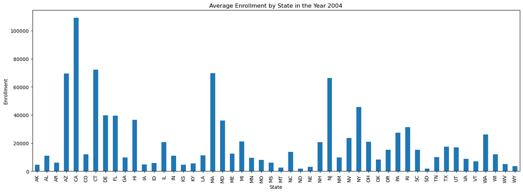

```python
visual_year = input('Year between 1987 and 2006: ')
count_state = census_combined_list[0].loc[census_combined_list[0]['year'] == int(visual_year), ['enrollment', 'state']]
mean_enrollment_by_state = count_state.groupby('state')['enrollment'].mean().round()
mean_enrollment_by_state.plot.bar(figsize = (18,6))
plt.title(f'Average Enrollment by State in the Year {visual_year}')
plt.xlabel('State')
plt.ylabel('Enrollment')
plt.show()
```

## Double Check That It Generalizes!

We will now check that our `combine_dataframes()` function generalizes by reading in four census data sets containing resident total population estimates. Note that our `wrapper()` function has a default of `values_name = 'count'`, which we will use for all four data sets to ensure that all data sets read in will have the same variable name for this new variable.

```python
PST01a = wrapper('https://www4.stat.ncsu.edu/~online/datasets/PST01a.csv')
PST01b = wrapper('https://www4.stat.ncsu.edu/~online/datasets/PST01b.csv')
PST01c = wrapper('https://www4.stat.ncsu.edu/~online/datasets/PST01c.csv')
PST01d = wrapper('https://www4.stat.ncsu.edu/~online/datasets/PST01d.csv')

combine_dataframes(PST01a, PST01b, PST01c, PST01d)
```

```
[            area_name  STCOU  count  year measurement state
 2         Autauga, AL   1001  25508  1971     PST0151    AL
 3         Baldwin, AL   1003  60141  1971     PST0151    AL
 4         Barbour, AL   1005  23092  1971     PST0151    AL
 5            Bibb, AL   1007  13919  1971     PST0151    AL
 6          Blount, AL   1009  27817  1971     PST0151    AL
 ...               ...    ...    ...   ...         ...   ...
 31975  Sweetwater, WY  56037  41226  2009     PST0452    WY
 31976       Teton, WY  56039  20710  2009     PST0452    WY
 31977       Uinta, WY  56041  20927  2009     PST0452    WY
 31978    Washakie, WY  56043   7911  2009     PST0452    WY
 31979      Weston, WY  56045   7009  2009     PST0452    WY

 [125800 rows x 6 columns],
            area_name  STCOU      count  year measurement    division
 0      UNITED STATES      0  206827028  1971     PST0151       ERROR
 1            ALABAMA   1000    3497452  1971     PST0151  Division_6
 69            ALASKA   2000     316494  1971     PST0151  Division_9
 99           ARIZONA   4000    1896108  1971     PST0151  Division_8
 115         ARKANSAS   5000    1972028  1971     PST0151  Division_7
 ...              ...    ...        ...   ...         ...         ...
 31650       VIRGINIA  51000    7882590  2009     PST0452  Division_5
 31787     WASHINGTON  53000    6664195  2009     PST0452  Division_9
 31827  WEST VIRGINIA  54000    1819777  2009     PST0452  Division_5
 31883      WISCONSIN  55000    5654774  2009     PST0452  Division_3
 31956        WYOMING  56000     544270  2009     PST0452  Division_8

 [2120 rows x 6 columns]]
```

# Part 4: Cross-Validation

We will now fit two linear regression models on our `non_county` data from the `census_combined_list` and judge them using our own cross-validation function. Before we actually create the `cv_error()` function we will walk through the steps of creating a single linear regression model as well as a multiple linear regression model.

## Subset of Data

We will use the education `enrollment` data sets from earlier, stored as the list `census_combined_list`. First, we will subset the list so that we are only looking at the non-county level data. Next, we will remove any rows where the division variable is `ERROR` and select only the `year`, `division`, and `enrollment` variables. We will store this subsetted data as `cv_subset`. We can use the `.unique()` method to check and make sure we only have `Division_1`, through `Division_9` in our data set.

```python
cv_subset = census_combined_list[1].loc[census_combined_list[1]['division']!='ERROR', ['year', 'division', 'enrollment']]
print(cv_subset.division.sort_values().unique())
```

```
['Division_1' 'Division_2' 'Division_3' 'Division_4' 'Division_5'
 'Division_6' 'Division_7' 'Division_8' 'Division_9']
```

```python
cv_subset.head()
```

|  | year | division | enrollment |
| --- | --- | --- | --- |
| 1 | 1987 | Division_6 | 733735 |
| 69 | 1987 | Division_9 | 102872 |
| 99 | 1987 | Division_8 | 609411 |
| 115 | 1987 | Division_7 | 429260 |
| 191 | 1987 | Division_9 | 4621126 |

#### Enrollment Numbers by Division

Before we start building our models, let's take quick look at average `enrollment` by `division` for a given year. This visualization allows you to select a year between 1987 and 2006 in order to create a bar graph to look at a comparison of `enrollment` numbers by `division` for your selected year.

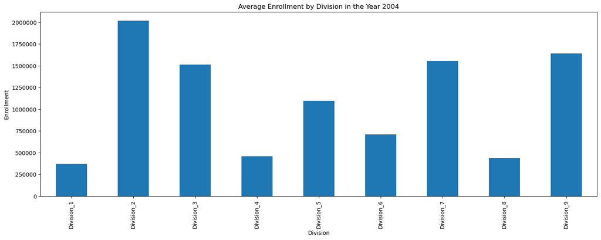

```python
visual_year = input('Year between 1987 and 2006: ')
count_division = cv_subset.loc[cv_subset['year'] == int(visual_year), ['enrollment', 'division']]
mean_enrollment_by_division = count_division.groupby('division')['enrollment'].mean().round()
mean_enrollment_by_division.plot.bar(figsize = (18,6))
plt.title(f'Average Enrollment by Division in the Year {visual_year}')
plt.xlabel('Division')
plt.ylabel('Enrollment')
plt.ticklabel_format(style='plain', axis='y')
plt.show()
```

## Two Models Under Consideration

We will use two competing models:

- A SLR model using `year` to predict `enrollment`
- An MLR model using `year` and `division` to predict `enrollment`

### Importing `linear_model` Class From `sklearn` Module

To create our linear models we will use the `linear_model` class from the `sklearn` package. We imported everthing that we needed for the analysis before beginning work on the data sets. The code to import this funtion from `sklearn` is:

```
from sklearn import linear_model
```

This will load the `linear_model` class into the current namespace. The `linear_model` class included functions to create different types of linear models. We will use the `LinearRegression()` function to create our regression object, and then the `.fit()` method to fit our models based on the regression objects created.

### SLR Model Using `year` to predict `enrollment`

Note that we have included this to demonstrate how this process works, so that when we use this in our `get_MSE()` function it will be more clear what needs to be referenced to fit a SLR model for `enrollment` based on the predictor variable `year`.

```python
SLR_model = linear_model.LinearRegression()#Create a regression object
SLR_model.fit(X = cv_subset.loc[:, ['year']], y = cv_subset['enrollment'].values)#Fit our SLR model
print(SLR_model.intercept_, SLR_model.coef_[0])#Look at coefficients of our model
```

```
-20659916.0188421 10794.73389473684
```

### MLR Model Using `year` and `division` to predict `enrollment`

Our MLR model will use `year` and `division` to predict `enrollment`. Before we can build and fit our model we need to create a matrix of dummy variables corresponding to our observations of our `division` variable.

### Creating a Dummy Variable for the `division` Variable with `get_dummies()` Function

The `get_dummies()` function from `pandas` can allow us to eaisly create dummy variables for a variable in our data set. We will use the `get_dummies()` function to create dummy variables based on the values of our `division` variable.

This function will return a dataframe in which each row will contain a 1 in the column for its `division` and zeros for all other division columns. As a result, we really only need columns for our number of divisions minus one because we will be able to determine the remaining division affiliation based on the other columns. For example, if we leave off the column for `Division_9` and the values for `Division_1` through `Division_8` are all zero for a given observation, we know that the observation is a part of `Division_9`.

```python
division_dummies = pd.get_dummies(data = cv_subset['division'])
division_dummies.loc[:, 'Division1':'Division_8']
```

|  | Division_1 | Division_2 | Division_3 | Division_4 | Division_5 | Division_6 | Division_7 | Division_8 |
| --- | --- | --- | --- | --- | --- | --- | --- | --- |
| 1 | 0 | 0 | 0 | 0 | 0 | 1 | 0 | 0 |
| 69 | 0 | 0 | 0 | 0 | 0 | 0 | 0 | 0 |
| 99 | 0 | 0 | 0 | 0 | 0 | 0 | 0 | 1 |
| 115 | 0 | 0 | 0 | 0 | 0 | 0 | 1 | 0 |
| 191 | 0 | 0 | 0 | 0 | 0 | 0 | 0 | 0 |
| ... | ... | ... | ... | ... | ... | ... | ... | ... |
| 31650 | 0 | 0 | 0 | 0 | 1 | 0 | 0 | 0 |
| 31787 | 0 | 0 | 0 | 0 | 0 | 0 | 0 | 0 |
| 31827 | 0 | 0 | 0 | 0 | 1 | 0 | 0 | 0 |
| 31883 | 0 | 0 | 1 | 0 | 0 | 0 | 0 | 0 |
| 31956 | 0 | 0 | 0 | 0 | 0 | 0 | 0 | 1 |

1000 rows × 8 columns

Before we create our MLR model, lets add the dummy variables to our `cv_subset` data set. The `div1_dummy` through `div8_dummy` variables will have columns for `Division_1` through `Division_8`. Membership in `Division_9` will be determined for observations with values of 0 for all `div_dummy` variables.

```python
div_dummies = ['div1_dummy', 'div2_dummy', 'div3_dummy', 'div4_dummy', 'div5_dummy', 'div6_dummy', 'div7_dummy', 'div8_dummy']
cv_subset[div_dummies] = division_dummies.loc[:, 'Division1':'Division_8']
cv_subset.loc[:, ['year'] + div_dummies]
```

|  | year | div1_dummy | div2_dummy | div3_dummy | div4_dummy | div5_dummy | div6_dummy | div7_dummy | div8_dummy |
| --- | --- | --- | --- | --- | --- | --- | --- | --- | --- |
| 1 | 1987 | 0 | 0 | 0 | 0 | 0 | 1 | 0 | 0 |
| 69 | 1987 | 0 | 0 | 0 | 0 | 0 | 0 | 0 | 0 |
| 99 | 1987 | 0 | 0 | 0 | 0 | 0 | 0 | 0 | 1 |
| 115 | 1987 | 0 | 0 | 0 | 0 | 0 | 0 | 1 | 0 |
| 191 | 1987 | 0 | 0 | 0 | 0 | 0 | 0 | 0 | 0 |
| ... | ... | ... | ... | ... | ... | ... | ... | ... | ... |
| 31650 | 2006 | 0 | 0 | 0 | 0 | 1 | 0 | 0 | 0 |
| 31787 | 2006 | 0 | 0 | 0 | 0 | 0 | 0 | 0 | 0 |
| 31827 | 2006 | 0 | 0 | 0 | 0 | 1 | 0 | 0 | 0 |
| 31883 | 2006 | 0 | 0 | 1 | 0 | 0 | 0 | 0 | 0 |
| 31956 | 2006 | 0 | 0 | 0 | 0 | 0 | 0 | 0 | 1 |

1000 rows × 9 columns

Before we build our MLR model, let's make sure that the `cv_subset` data frame looks as expected.

```python
cv_subset.head()
```

|  | year | division | enrollment | div1_dummy | div2_dummy | div3_dummy | div4_dummy | div5_dummy | div6_dummy | div7_dummy | div8_dummy |
| --- | --- | --- | --- | --- | --- | --- | --- | --- | --- | --- | --- |
| 1 | 1987 | Division_6 | 733735 | 0 | 0 | 0 | 0 | 0 | 1 | 0 | 0 |
| 69 | 1987 | Division_9 | 102872 | 0 | 0 | 0 | 0 | 0 | 0 | 0 | 0 |
| 99 | 1987 | Division_8 | 609411 | 0 | 0 | 0 | 0 | 0 | 0 | 0 | 1 |
| 115 | 1987 | Division_7 | 429260 | 0 | 0 | 0 | 0 | 0 | 0 | 1 | 0 |
| 191 | 1987 | Division_9 | 4621126 | 0 | 0 | 0 | 0 | 0 | 0 | 0 | 0 |

## MLR Model

As noted above with the SLR model, the MLR model is provided here to see how to format `.fit()` to generate an MLR model predicting `enrollment` based on the `year` and `division` predictor variables. This will be helpful to reference when creating the `get_MSE()` helper function.

```python
MLR_model = linear_model.LinearRegression()#Create regression object
MLR_model.fit(cv_subset.loc[:, ['year'] + div_dummies], cv_subset['enrollment'].values)#Fit MLR model
print(MLR_model.intercept_, MLR_model.coef_)#Print model coefficients
```

```
-20095145.920842096 [   10794.73389474 -1107855.75         437619.58333334     2187.28000001
 -1005594.80714286  -497888.49375     -766572.2875       -48516.425
 -1079067.3875    ]
```

## Creating a `cross_validation()` Function

We want to see how well our `SLR_model` and `MLR_model` predict our `enrollment` values. Because our data is over time we will want to create a function to train the model and judge sequantially by year.

### The `get_MSE()` Helper Function

The `get_MSE` function will take in a dataframe of predictors (`X`), a 1D response (`y`), and a `last_year` argument. The `get_MSE()` function will raise an error if the `last_year` entered is greater than 2005, as the education data set only contains years 1987-2006 and the last test set generated will contain information from 2006 (equivalent to `last_year + 1`).

We will need to import the `mean_squared_error()` function from `sklearn.metrics` to help in our `get_MSE()` function. Note that we imported all required packages and functions at the beginning, so we will not repeat it here. The code import this function is:

```
    from sklearn.metrics import mean_squared_error
```

To create our training set we will include all years up to and including the `last_year`. The test set will only include the `last_year` + 1, or the year after the `last_year` entered. As there are many steps within the `get_MSE()` function, we have provided additional commented notes within the code block for clarity.

```python
def get_MSE(X, Y, last_year):
    """
    Returns the MSE by joining a data frame of predictors and 1D response.
    Creates a training set based on the years prior to, and including, the 'last_year' specified.
    Creates a test set based on the year after the 'last_year' specified.
    """
    if last_year > 2005:
        raise Exception("The last year cannot be greater than 2005!")
    # Creating training and test sets
    data_set = pd.concat([X, Y], axis=1)# Creating a dataset combining the X and Y data frames provided by the user.
    training_set = data_set.loc[data_set['year'] < (last_year + 1)]# Creating our training set
    test_set = data_set.loc[data_set['year'] == last_year + 1]# Creating our test set

    # Creating our linear regression model
    reg = linear_model.LinearRegression()
    reg.fit(training_set.iloc[:, :-1], training_set['enrollment'].values)

    # Creating predictions for our test_set based on our model (reg)
    pred1 = reg.predict(test_set.iloc[:, :-1])

    # Getting MSE from our test_set using the true enrollment values from test_set and the predicted y values from our model
    MSE = mean_squared_error(y_true = test_set['enrollment'], y_pred = pred1)
    return(MSE)
```

#### Creating our predictor and response dataframes for the `get_MSE()` function

We need to create our data frames for the `get_MSE()` function. For the SLR model we will only have one predictor variable `year`. The MLR model will have two predictor variables, `year` and `division`. We will create our `X` predictor data frames using `.loc[]` to subset our `cv_subset` data frame by our predictor variables. We will store the predictors for the SLR model as `SLR_X_predictors` and the predictor data frame for our MLR model as `MLR_X_predictors`. We will create a 1D response, a `pandas series` called `response_Y`, by subsetting the `cv_subset` data frame by `enrollment`.

```python
SLR_X_predictors = cv_subset.loc[:, ['year']]
MLR_X_predictors = cv_subset.loc[:, ['year'] + div_dummies]
response_Y = cv_subset['enrollment']
```

Quick test of `get_MSE()` function

```python
get_MSE(MLR_X_predictors, response_Y, 2005)
```

```
976996778056.927
```

```python
get_MSE(SLR_X_predictors, response_Y, 1990)
```

```
782273183690.5989
```

## The `cv_error()` Function

This data set is based on `enrollment` values over time, and so the traditional train vs test set approach or built-in cross validation functions will not be appropriate because we need to account for the `year` when creating these groups, and not simply randomly split our data into training or test sets, or k-folds in cross-validation. We will need to write a function to train our models and judge them sequentially.

The `cv_error()` function will obtain the CV value over all the years (other than the initial training block of the first three years of data). The `cv-error()` function will handle this for us by taking data from the first three years (acting as a training set) and using that to predict the `enrollment` for the fourth year (acting as our test set). It will then use the `get_MSE()` helper function to generate an MSE value for this "test set" based on the model created by the "training set". The `cv_error()` function will then move on to the next fold, and use the first four years to predict the fifth year, calculate the MSE for the predictions, and add this MSE to the MSE value from the first iteration of the loop using augmented assignment. It will continue in this manner until it reaches the last year of the data set. The `cv_error()` function will return the summed MSE values to give us the overall MSE for the model.

```python
def cv_error(X, Y, first_year):
    """
    Returns the summed MSE values by iterating through the values between
    the 'first_year' specified and the last year in the 'year' column of the
    data frame, so long as the year is not less than 1989.
    The MSE for each year is found using the get_MSE() helper function.
    """
    if first_year < 1989:
        raise Exception("The first year must be greater than 1989!")

    MSE = 0

    for i in range(first_year, X['year'].max()):
        yearly_MSE = get_MSE(X, Y, i)
        MSE += yearly_MSE
    return MSE
```

# Part 6: Comparing Models Using MSE

### SLR Model MSE

```python
SLR_Model_MSE = cv_error(SLR_X_predictors, response_Y, 1989)
print(f'SLR Model MSE is: {SLR_Model_MSE}')
```

```
SLR Model MSE is: 17529166024130.021
```

We can see that the MSE for our **SLR model** was **17529166024130.021**. This value represents mean squared difference between the actual values for `enrollment` and the predicted values for `enrollment` calculated for each year in our data set, other than the initial three year training block of years 1987-1989, and then summed to genreate a total model MSE by the `cv_error()` function.

The SLR model had a single predictor, `year`, to predict `enrollment`. As there is only one predictor in our model, `year`, each data point within a given `year` will have the same predicted `enrollment` value. This means that if there is a lot of variation in the data within each `year` in terms of `enrollment` that most data points will fall far from the fitted line of our model, and therefore generate larger MSE values. Additionally, the `enrollment` values themselves are large numbers, often in the hundreds of thousands to millions, and this would also contribute to a large MSE value, particularly when considering that MSE is a mean squared distance from the regression line for a given `year`'s `enrollment` numbers.

The MSE value for the SLR Model are large, so let's take a look at some information about these variables in our original data set to see if this is reasonable based on the data. First, let's look at a scatterplot of `year` and `enrollment` to see if we can see any clear patterns. We will use the `regplot()` function from `seaborn` to create a scatterplot with a regression line.

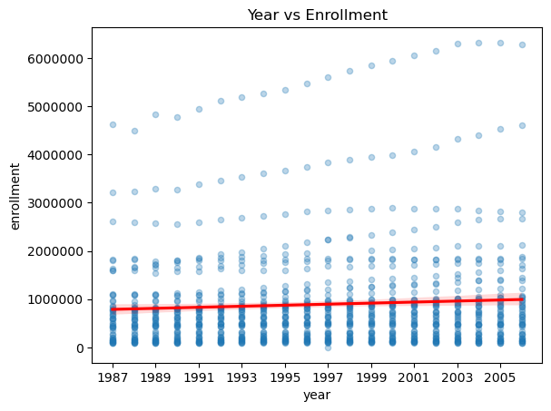

```python
sns.regplot(x=cv_subset['year'], y=cv_subset['enrollment'], scatter_kws={'s':20,'alpha':.3}, line_kws={'color':'red'})
plt.title('Year vs Enrollment')
plt.xticks(list(cv_subset.year.sort_values().unique())[::2])
plt.ticklabel_format(style='plain', axis='y')
plt.show()
```

We can see in the scatterplot that there is a lot of variablity in our `enrollment` values within each year, and it does not seem like a single line will have much predictive power for `enrollment` by `year`. The red line shows the predicted `enrollment` by `year`.

Below you can see a table containing numeric summarries of `enrollment` grouped by `year`. It is clear that there is a lot of variation in the `enrollment` variable within each `year`. We can see that for `1990` we have `enrollment` values ranging from a minimum of `94,776`, to a maximum of `4,771,978` with a mean of `813,125.98`. This high level of variation for `enrollment` variables that are also quite large would lead to high MSE values. Taken alone, the MSE value does not mean much, but we can use it to compare two different models based on the same data set and response variable.

```python
cv_subset \
    .groupby(['year']) \
    .agg({'enrollment':['std', 'mean', 'min', 'max']})
```

| year | enrollment std | enrollment mean | enrollment min | enrollment max |
| --- | --- | --- | --- | --- |
| 1987 | 8.524373e+05 | 798773.74 | 91308 | 4621126 |
| 1988 | 8.427027e+05 | 797623.78 | 90401 | 4488398 |
| 1989 | 8.722160e+05 | 804659.66 | 85786 | 4833981 |
| 1990 | 8.662249e+05 | 813125.98 | 94776 | 4771978 |
| 1991 | 8.933842e+05 | 826094.96 | 93666 | 4949910 |
| 1992 | 9.198885e+05 | 840150.66 | 97137 | 5108228 |
| 1993 | 9.346720e+05 | 852875.46 | 100729 | 5195777 |
| 1994 | 9.489968e+05 | 865784.78 | 100899 | 5268501 |
| 1995 | 9.642301e+05 | 878260.18 | 100369 | 5342071 |
| 1996 | 9.853942e+05 | 892718.70 | 99859 | 5468287 |
| 1997 | 1.022391e+06 | 889116.22 | 0 | 5614060 |
| 1998 | 1.033015e+06 | 923374.06 | 97115 | 5728378 |
| 1999 | 1.043573e+06 | 925940.28 | 94988 | 5844111 |
| 2000 | 1.059173e+06 | 934829.92 | 92283 | 5953225 |
| 2001 | 1.074882e+06 | 941162.82 | 89940 | 6051710 |
| 2002 | 1.093470e+06 | 950623.56 | 87897 | 6148158 |
| 2003 | 1.124349e+06 | 968565.20 | 87462 | 6298928 |
| 2004 | 1.130917e+06 | 972331.46 | 84733 | 6322189 |
| 2005 | 1.138568e+06 | 978033.58 | 86420 | 6312103 |
| 2006 | 1.141070e+06 | 981359.04 | 85193 | 6287004 |

### MLR Model MSE

```python
MLR_Model_MSE = cv_error(MLR_X_predictors, response_Y, 1989)
print(f'MLR Model MSE is: {MLR_Model_MSE}')
print(f'MLR Model RMSE is: {round(np.sqrt(MLR_Model_MSE))}')
```

```
MLR Model MSE is: 13087317177409.227
MLR Model RMSE is: 3617640
```

Now let's take a look at how the MLR model MSE compares to the previous SLR model.

The MLR model has two predictors, `year` and `division`, that are used to predict `enrollment`. Like before, if there is a lot of variation in `enrollment` within our prediction groups (in this case within a given `year` and `division`) then we would still expect to return large MSE values.

We can see that the MSE for our MLR model was **13087317177409.227**. This value is lower than the MSE for the SLR model. Our MLR model was built using both `year` and `division` to predict enrollment. Let's look at a quick plot of `year` vs `enrollment` colored by `division` to give us an idea of the variation within our `division` subgroups each `year`. The plot also contains one regression line for each of our 9 `division`s.

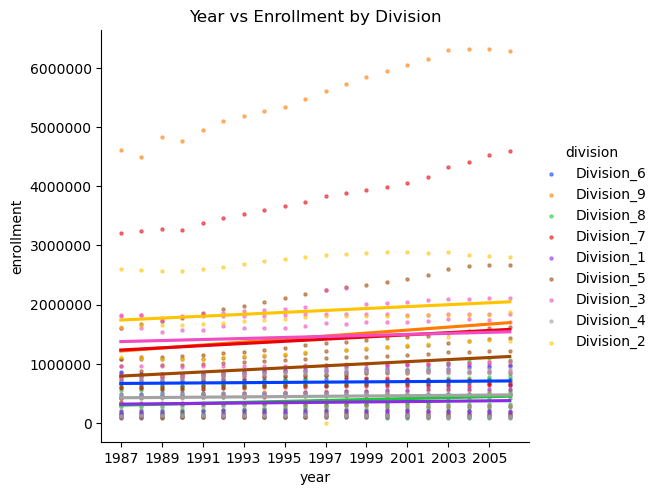

| year | division | enrollment std | enrollment mean | enrollment min | enrollment max |
| --- | --- | --- | --- | --- | --- |
| 1987 | Division_1 | 2.895288e+05 | 3.134530e+05 | 91308 | 846430 |
|  | Division_2 | 7.614172e+05 | 1.781789e+06 | 1107328 | 2607469 |
|  | Division_3 | 4.961610e+05 | 1.395868e+06 | 767819 | 1830301 |
|  | Division_4 | 2.660765e+05 | 4.141421e+05 | 120007 | 800606 |
|  | Division_5 | 4.766845e+05 | 8.100218e+05 | 98111 | 1607115 |
| ... | ... | ... | ... | ... | ... |
| 2006 | Division_5 | 8.216103e+05 | 1.115568e+06 | 122254 | 2671513 |
|  | Division_6 | 2.026833e+05 | 7.159150e+05 | 495026 | 978368 |
|  | Division_7 | 2.003024e+06 | 1.597790e+06 | 476409 | 4599509 |
|  | Division_8 | 3.331549e+05 | 4.538565e+05 | 85193 | 1065082 |
|  | Division_9 | 2.623605e+06 | 1.637938e+06 | 132608 | 6287004 |

180 rows × 4 columns

```python
sns.lmplot(
    data=cv_subset,
    x='year',
    y='enrollment',
    hue='division',
    scatter_kws={'s':5,'alpha':.5},
    ci=None,
    palette='bright'
)
plt.title('Year vs Enrollment by Division')
plt.xticks(list(cv_subset.year.sort_values().unique())[::2])
plt.ticklabel_format(style='plain', axis='y')
plt.show()

cv_subset \
    .groupby(['year', 'division']) \
    .agg({'enrollment':['std', 'mean', 'min', 'max']})
```

We can see in the regression plot and the table that there is still a lot of variation *within* groups (`year` and `division`) under the MLR model, which would result in large MSE values. We can also see that there is a lot of variation *between* our divisions by year, and as such we would expect the multiple regession model to have a lower MSE as compared to the SLR model above that had `year` as the only predictor for `enrollment`, as the MLR model is helping to account for this variation in `enrollment` across `division`s.

### Comparing SLR Model to MLR Model

```python
print(f'SLR Model MSE is: {SLR_Model_MSE}\nMLR Model MSE is: {MLR_Model_MSE}')
print(f'The MLR MSE was {SLR_Model_MSE-MLR_Model_MSE} lower than the SLR model MSE')
```

```
SLR Model MSE is: 17529166024130.021
MLR Model MSE is: 13087317177409.227
The MLR MSE was 4441848846720.795 lower than the SLR model MSE
```

In comparing the two models created to predict the same response variable, we want to select the model with a lower MSE, as this would indicate overall predicted observations from the model closer to the true values from our test set. In this analysis, the MLR model overall MSE is **4,441,848,846,720.795** *lower* than the SLR model overall MSE and is the preferred model for predicting `enrollment`, especially considering the MLR used is easily interpretable.

As discussed previously, the large MSE values here are expected as there is a lot of variation in `enrollment` within subgroups of our data (within the `year` for the SLR model and within the `year` by `division` subgroup for the MLR model) and the `enrollment` values themselves are quites large, often in the hundreds of thousands. The `cv_error()` function is also calculating the overall MSE by summing together MSE values for each sequential year, with separate test sets from 1990 to 2006, futher increasing the resulting total model MSE values that are returned.

### MSE vs RMSE

MSE is measured in squared units. The RMSE is the square root of the MSE and can be more easy to interpret as it is in the same units as our data. RMSE measures the average difference between the values predicted by our model, and the actual values in our data that was not used to build our model (in our test or validation set). We can see below that on average, the SLR model predicted value for enrollment was 4,186,785 off from the actual `enrollment` value, while the MLR model prediction for `enrollment` was 3,617,640 off from the actual `enrollment` value. Again, these values for RMSE are high, but there was a very large amont of variation within our groups attempting to predict `enrollment` value, and most `enrollment` values were very large in themselves, so these large numbers are to be expected.

```python
print(f'SLR Model RMSE is: {round(np.sqrt(SLR_Model_MSE))}')
print(f'MLR Model RMSE is: {round(np.sqrt(MLR_Model_MSE))}')
```

```
SLR Model RMSE is: 4186785
MLR Model RMSE is: 3617640
```